# Risk Factor Analysis

## Outcome Variable

**Outcome Variable:** haz

## Predictor Variables

**Intervention Variable:** hfoodsec

**Adjustment Set:**

- arm
- sex
- W_mage
- meducyrs
- feducyrs
- hhwealth_quart
- vagbrth
- W_nrooms
- W_nchldlt5
- brthmon
- W_parity
- impfloor
- impsan
- safeh20
- delta_W_mage
- delta_meducyrs
- delta_feducyrs
- delta_hhwealth_quart
- delta_vagbrth
- delta_W_nrooms
- delta_W_nchldlt5
- delta_brthmon
- delta_W_parity
- delta_impfloor
- delta_impsan
- delta_safeh20

## Stratifying Variables

The analysis was stratified on these variable(s):

- agecat
- studyid
- country

## Data Summary

| agecat | studyid | country | hfoodsec | n_cell | n | outcome_variable |
| --- | --- | --- | --- | --- | --- | --- |
| Birth | GMS-Nepal | NEPAL | Food Secure | 477 | 672 | haz |
| Birth | GMS-Nepal | NEPAL | Mildly Food Insecure | 106 | 672 | haz |
| Birth | GMS-Nepal | NEPAL | Food Insecure | 89 | 672 | haz |
| Birth | JiVitA-3 | BANGLADESH | Food Secure | 6951 | 14364 | haz |
| Birth | JiVitA-3 | BANGLADESH | Mildly Food Insecure | 4877 | 14364 | haz |
| Birth | JiVitA-3 | BANGLADESH | Food Insecure | 2536 | 14364 | haz |
| Birth | JiVitA-4 | BANGLADESH | Food Secure | 1433 | 2810 | haz |
| Birth | JiVitA-4 | BANGLADESH | Mildly Food Insecure | 1018 | 2810 | haz |
| Birth | JiVitA-4 | BANGLADESH | Food Insecure | 359 | 2810 | haz |
| Birth | MAL-ED | BANGLADESH | Food Secure | 144 | 172 | haz |
| Birth | MAL-ED | BANGLADESH | Mildly Food Insecure | 4 | 172 | haz |
| Birth | MAL-ED | BANGLADESH | Food Insecure | 24 | 172 | haz |
| Birth | MAL-ED | BRAZIL | Food Secure | 0 | 28 | haz |
| Birth | MAL-ED | BRAZIL | Mildly Food Insecure | 4 | 28 | haz |
| Birth | MAL-ED | BRAZIL | Food Insecure | 24 | 28 | haz |
| Birth | MAL-ED | INDIA | Food Secure | 34 | 37 | haz |
| Birth | MAL-ED | INDIA | Mildly Food Insecure | 1 | 37 | haz |
| Birth | MAL-ED | INDIA | Food Insecure | 2 | 37 | haz |
| Birth | MAL-ED | NEPAL | Food Secure | 10 | 14 | haz |
| Birth | MAL-ED | NEPAL | Mildly Food Insecure | 1 | 14 | haz |
| Birth | MAL-ED | NEPAL | Food Insecure | 3 | 14 | haz |
| Birth | MAL-ED | PERU | Food Secure | 24 | 91 | haz |
| Birth | MAL-ED | PERU | Mildly Food Insecure | 23 | 91 | haz |
| Birth | MAL-ED | PERU | Food Insecure | 44 | 91 | haz |
| Birth | MAL-ED | SOUTH AFRICA | Food Secure | 45 | 88 | haz |
| Birth | MAL-ED | SOUTH AFRICA | Mildly Food Insecure | 9 | 88 | haz |
| Birth | MAL-ED | SOUTH AFRICA | Food Insecure | 34 | 88 | haz |
| Birth | NIH-Birth | BANGLADESH | Food Secure | 90 | 608 | haz |
| Birth | NIH-Birth | BANGLADESH | Mildly Food Insecure | 478 | 608 | haz |
| Birth | NIH-Birth | BANGLADESH | Food Insecure | 40 | 608 | haz |

[output cut: 69 more lines]

The following strata were considered:

- agecat: 24 months, studyid: GMS-Nepal, country: NEPAL
- agecat: 24 months, studyid: JiVitA-3, country: BANGLADESH
- agecat: 24 months, studyid: JiVitA-4, country: BANGLADESH
- agecat: 24 months, studyid: MAL-ED, country: BANGLADESH
- agecat: 24 months, studyid: MAL-ED, country: BRAZIL
- agecat: 24 months, studyid: MAL-ED, country: INDIA
- agecat: 24 months, studyid: MAL-ED, country: NEPAL
- agecat: 24 months, studyid: MAL-ED, country: PERU
- agecat: 24 months, studyid: MAL-ED, country: SOUTH AFRICA
- agecat: 24 months, studyid: NIH-Birth, country: BANGLADESH
- agecat: 24 months, studyid: NIH-Crypto, country: BANGLADESH
- agecat: 6 months, studyid: GMS-Nepal, country: NEPAL
- agecat: 6 months, studyid: JiVitA-3, country: BANGLADESH
- agecat: 6 months, studyid: JiVitA-4, country: BANGLADESH
- agecat: 6 months, studyid: MAL-ED, country: BANGLADESH
- agecat: 6 months, studyid: MAL-ED, country: BRAZIL
- agecat: 6 months, studyid: MAL-ED, country: INDIA
- agecat: 6 months, studyid: MAL-ED, country: NEPAL
- agecat: 6 months, studyid: MAL-ED, country: PERU
- agecat: 6 months, studyid: MAL-ED, country: SOUTH AFRICA
- agecat: 6 months, studyid: NIH-Birth, country: BANGLADESH
- agecat: 6 months, studyid: NIH-Crypto, country: BANGLADESH
- agecat: Birth, studyid: GMS-Nepal, country: NEPAL
- agecat: Birth, studyid: JiVitA-3, country: BANGLADESH
- agecat: Birth, studyid: JiVitA-4, country: BANGLADESH
- agecat: Birth, studyid: MAL-ED, country: BANGLADESH
- agecat: Birth, studyid: MAL-ED, country: BRAZIL
- agecat: Birth, studyid: MAL-ED, country: INDIA
- agecat: Birth, studyid: MAL-ED, country: NEPAL
- agecat: Birth, studyid: MAL-ED, country: PERU
- agecat: Birth, studyid: MAL-ED, country: SOUTH AFRICA
- agecat: Birth, studyid: NIH-Birth, country: BANGLADESH
- agecat: Birth, studyid: NIH-Crypto, country: BANGLADESH

### Dropped Strata

Some strata were dropped due to rare outcomes:

- agecat: Birth, studyid: MAL-ED, country: BANGLADESH
- agecat: Birth, studyid: MAL-ED, country: BRAZIL
- agecat: Birth, studyid: MAL-ED, country: INDIA
- agecat: Birth, studyid: MAL-ED, country: NEPAL
- agecat: 6 months, studyid: MAL-ED, country: BANGLADESH
- agecat: 6 months, studyid: MAL-ED, country: BRAZIL
- agecat: 24 months, studyid: MAL-ED, country: BANGLADESH
- agecat: 24 months, studyid: MAL-ED, country: BRAZIL

## Methods Detail

We’re interested in the causal parameters $E[Y_a]$ for all values of $a \in \mathcal{A}$. These parameters represent the mean outcome if, possibly contrary to fact, we intervened to set all units to have $A=a$. Under the randomization and positivity assumptions, these are identified by the statistical parameters $\psi_a=E_W[E_{Y|A,W}(Y|A=a,W)]$. In addition, we’re interested in the mean of $Y$, $E[Y]$ under no intervention (the observed mean). We will estimate these parameters by using SuperLearner to fit the relevant likelihood factors – $E_{Y|A,W}(Y|A=a,W)$ and $p(A=a|W)$, and then updating our likelihood fit using a joint TMLE.

For unadjusted analyses ($W=\{\}$), initial likelihoods were estimated using Lrnr_glm to estimate the simple $E(Y|A)$ and Lrnr_mean to estimate $p(A)$. For adjusted analyses, a small library containing Lrnr_glmnet, Lrnr_xgboost, and Lrnr_mean was used.

Having estimated these parameters, we will then use the delta method to estimate relative risks and attributable risks relative to a prespecified baseline level of $A$.

# Results Detail

## Results Plots

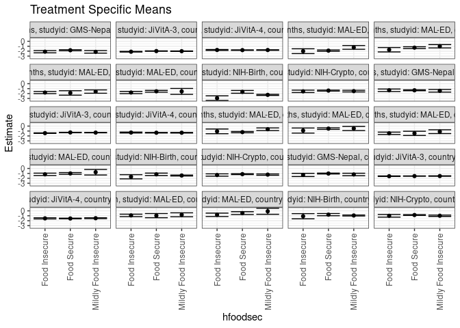

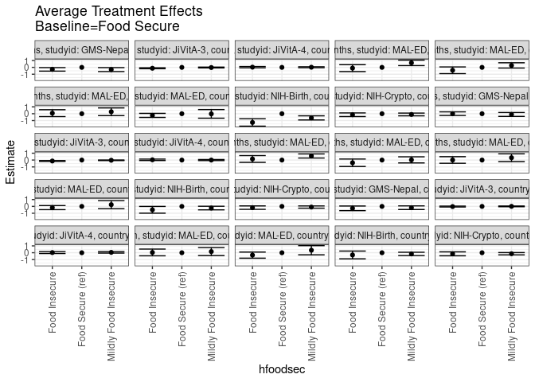

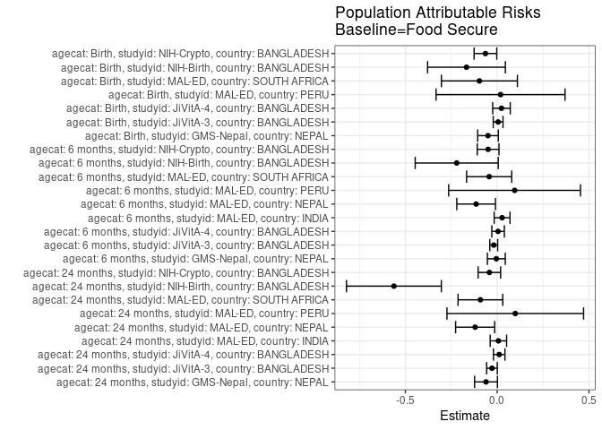

## Results Table

### Parameter: TSM

| agecat | studyid | country | intervention_level | baseline_level | estimate | ci_lower | ci_upper |
| --- | --- | --- | --- | --- | --- | --- | --- |
| Birth | GMS-Nepal | NEPAL | Food Secure | NA | -1.0291636 | -1.1240473 | -0.9342799 |
| Birth | GMS-Nepal | NEPAL | Mildly Food Insecure | NA | -1.2188974 | -1.4681704 | -0.9696243 |
| Birth | GMS-Nepal | NEPAL | Food Insecure | NA | -1.3104079 | -1.6342413 | -0.9865746 |
| Birth | JiVitA-3 | BANGLADESH | Food Secure | NA | -1.5426315 | -1.5764187 | -1.5088444 |
| Birth | JiVitA-3 | BANGLADESH | Mildly Food Insecure | NA | -1.5379872 | -1.5783681 | -1.4976063 |
| Birth | JiVitA-3 | BANGLADESH | Food Insecure | NA | -1.5671193 | -1.6222806 | -1.5119579 |
| Birth | JiVitA-4 | BANGLADESH | Food Secure | NA | -1.5483451 | -1.6164038 | -1.4802864 |
| Birth | JiVitA-4 | BANGLADESH | Mildly Food Insecure | NA | -1.4921950 | -1.5772644 | -1.4071257 |
| Birth | JiVitA-4 | BANGLADESH | Food Insecure | NA | -1.5228715 | -1.6434033 | -1.4023397 |
| Birth | MAL-ED | PERU | Food Secure | NA | -0.9673453 | -1.3889206 | -0.5457699 |
| Birth | MAL-ED | PERU | Mildly Food Insecure | NA | -0.7997735 | -1.2001780 | -0.3993690 |
| Birth | MAL-ED | PERU | Food Insecure | NA | -0.9232616 | -1.1753947 | -0.6711286 |
| Birth | MAL-ED | SOUTH AFRICA | Food Secure | NA | -0.4535556 | -0.7370575 | -0.1700536 |
| Birth | MAL-ED | SOUTH AFRICA | Mildly Food Insecure | NA | -0.0888889 | -0.6955550 | 0.5177773 |
| Birth | MAL-ED | SOUTH AFRICA | Food Insecure | NA | -0.8005882 | -1.1433809 | -0.4577955 |
| Birth | NIH-Birth | BANGLADESH | Food Secure | NA | -0.7638195 | -0.9852039 | -0.5424351 |
| Birth | NIH-Birth | BANGLADESH | Mildly Food Insecure | NA | -0.9392418 | -1.0404936 | -0.8379899 |
| Birth | NIH-Birth | BANGLADESH | Food Insecure | NA | -1.0884578 | -1.6129504 | -0.5639652 |
| Birth | NIH-Crypto | BANGLADESH | Food Secure | NA | -0.8454881 | -0.9349234 | -0.7560527 |
| Birth | NIH-Crypto | BANGLADESH | Mildly Food Insecure | NA | -0.9910752 | -1.1300273 | -0.8521231 |
| Birth | NIH-Crypto | BANGLADESH | Food Insecure | NA | -1.0037908 | -1.2758254 | -0.7317563 |
| 6 months | GMS-Nepal | NEPAL | Food Secure | NA | -1.3376224 | -1.4289411 | -1.2463037 |
| 6 months | GMS-Nepal | NEPAL | Mildly Food Insecure | NA | -1.4475703 | -1.7152206 | -1.1799200 |
| 6 months | GMS-Nepal | NEPAL | Food Insecure | NA | -1.3338242 | -1.5819480 | -1.0857005 |
| 6 months | JiVitA-3 | BANGLADESH | Food Secure | NA | -1.2944200 | -1.3253983 | -1.2634418 |
| 6 months | JiVitA-3 | BANGLADESH | Mildly Food Insecure | NA | -1.3257441 | -1.3613050 | -1.2901831 |
| 6 months | JiVitA-3 | BANGLADESH | Food Insecure | NA | -1.4331849 | -1.4881368 | -1.3782329 |
| 6 months | JiVitA-4 | BANGLADESH | Food Secure | NA | -1.3495974 | -1.4012656 | -1.2979292 |
| 6 months | JiVitA-4 | BANGLADESH | Mildly Food Insecure | NA | -1.3502370 | -1.4096577 | -1.2908162 |
| 6 months | JiVitA-4 | BANGLADESH | Food Insecure | NA | -1.3123254 | -1.4005999 | -1.2240509 |
| 6 months | MAL-ED | INDIA | Food Secure | NA | -1.2287544 | -1.3589893 | -1.0985195 |
| 6 months | MAL-ED | INDIA | Mildly Food Insecure | NA | -0.6360000 | -0.9019405 | -0.3700595 |
| 6 months | MAL-ED | INDIA | Food Insecure | NA | -1.0694118 | -1.5456747 | -0.5931488 |
| 6 months | MAL-ED | NEPAL | Food Secure | NA | -0.5115396 | -0.6714227 | -0.3516564 |
| 6 months | MAL-ED | NEPAL | Mildly Food Insecure | NA | -0.4855027 | -0.9026856 | -0.0683199 |
| 6 months | MAL-ED | NEPAL | Food Insecure | NA | -0.9064228 | -1.4229799 | -0.3898657 |
| 6 months | MAL-ED | PERU | Food Secure | NA | -1.4732433 | -1.8987523 | -1.0477344 |
| 6 months | MAL-ED | PERU | Mildly Food Insecure | NA | -1.1328576 | -1.5180915 | -0.7476237 |
| 6 months | MAL-ED | PERU | Food Insecure | NA | -1.4636247 | -1.6989570 | -1.2282923 |
| 6 months | MAL-ED | SOUTH AFRICA | Food Secure | NA | -1.0102858 | -1.1879045 | -0.8326671 |
| 6 months | MAL-ED | SOUTH AFRICA | Mildly Food Insecure | NA | -0.7584475 | -1.3199818 | -0.1969131 |
| 6 months | MAL-ED | SOUTH AFRICA | Food Insecure | NA | -1.1877676 | -1.4270334 | -0.9485018 |
| 6 months | NIH-Birth | BANGLADESH | Food Secure | NA | -1.1869657 | -1.4329849 | -0.9409465 |
| 6 months | NIH-Birth | BANGLADESH | Mildly Food Insecure | NA | -1.4296487 | -1.5259977 | -1.3332996 |
| 6 months | NIH-Birth | BANGLADESH | Food Insecure | NA | -1.6850880 | -2.1100041 | -1.2601720 |
| 6 months | NIH-Crypto | BANGLADESH | Food Secure | NA | -1.1493775 | -1.2414107 | -1.0573443 |
| 6 months | NIH-Crypto | BANGLADESH | Mildly Food Insecure | NA | -1.2453911 | -1.3801378 | -1.1106444 |
| 6 months | NIH-Crypto | BANGLADESH | Food Insecure | NA | -1.3286355 | -1.5622471 | -1.0950239 |
| 24 months | GMS-Nepal | NEPAL | Food Secure | NA | -1.8150408 | -1.9219306 | -1.7081511 |
| 24 months | GMS-Nepal | NEPAL | Mildly Food Insecure | NA | -2.1379848 | -2.4012897 | -1.8746800 |
| 24 months | GMS-Nepal | NEPAL | Food Insecure | NA | -2.1052764 | -2.3378327 | -1.8727201 |
| 24 months | JiVitA-3 | BANGLADESH | Food Secure | NA | -1.9815874 | -2.0219325 | -1.9412423 |
| 24 months | JiVitA-3 | BANGLADESH | Mildly Food Insecure | NA | -2.0044656 | -2.0512433 | -1.9576880 |
| 24 months | JiVitA-3 | BANGLADESH | Food Insecure | NA | -2.1106796 | -2.1751460 | -2.0462131 |
| 24 months | JiVitA-4 | BANGLADESH | Food Secure | NA | -1.7912307 | -1.8403482 | -1.7421132 |
| 24 months | JiVitA-4 | BANGLADESH | Mildly Food Insecure | NA | -1.7721313 | -1.8265317 | -1.7177309 |
| 24 months | JiVitA-4 | BANGLADESH | Food Insecure | NA | -1.7610765 | -1.8474967 | -1.6746562 |
| 24 months | MAL-ED | INDIA | Food Secure | NA | -1.8935000 | -2.0301943 | -1.7568057 |
| 24 months | MAL-ED | INDIA | Mildly Food Insecure | NA | -1.2370000 | -1.6132318 | -0.8607682 |
| 24 months | MAL-ED | INDIA | Food Insecure | NA | -2.0035294 | -2.4884028 | -1.5186561 |
| 24 months | MAL-ED | NEPAL | Food Secure | NA | -1.2891931 | -1.4737229 | -1.1046634 |
| 24 months | MAL-ED | NEPAL | Mildly Food Insecure | NA | -1.0038865 | -1.3385680 | -0.6692050 |
| 24 months | MAL-ED | NEPAL | Food Insecure | NA | -1.7125799 | -2.1579609 | -1.2671988 |
| 24 months | MAL-ED | PERU | Food Secure | NA | -1.8769895 | -2.3252534 | -1.4287255 |
| 24 months | MAL-ED | PERU | Mildly Food Insecure | NA | -1.5954624 | -1.9335361 | -1.2573887 |
| 24 months | MAL-ED | PERU | Food Insecure | NA | -1.7962618 | -2.0195864 | -1.5729372 |
| 24 months | MAL-ED | SOUTH AFRICA | Food Secure | NA | -1.5417903 | -1.7246390 | -1.3589416 |
| 24 months | MAL-ED | SOUTH AFRICA | Mildly Food Insecure | NA | -1.5656368 | -2.1684052 | -0.9628685 |
| 24 months | MAL-ED | SOUTH AFRICA | Food Insecure | NA | -1.7880556 | -2.0160380 | -1.5600733 |
| 24 months | NIH-Birth | BANGLADESH | Food Secure | NA | -1.6565989 | -1.9395432 | -1.3736546 |
| 24 months | NIH-Birth | BANGLADESH | Mildly Food Insecure | NA | -2.2667695 | -2.3763404 | -2.1571986 |
| 24 months | NIH-Birth | BANGLADESH | Food Insecure | NA | -2.9311567 | -3.3947217 | -2.4675917 |
| 24 months | NIH-Crypto | BANGLADESH | Food Secure | NA | -1.3988039 | -1.5030090 | -1.2945989 |
| 24 months | NIH-Crypto | BANGLADESH | Mildly Food Insecure | NA | -1.5065834 | -1.6785016 | -1.3346652 |
| 24 months | NIH-Crypto | BANGLADESH | Food Insecure | NA | -1.5493508 | -1.7940649 | -1.3046367 |

### Parameter: E(Y)

| agecat | studyid | country | intervention_level | baseline_level | estimate | ci_lower | ci_upper |
| --- | --- | --- | --- | --- | --- | --- | --- |
| Birth | GMS-Nepal | NEPAL | NA | NA | -1.0791964 | -1.1604792 | -0.9979137 |
| Birth | JiVitA-3 | BANGLADESH | NA | NA | -1.5375132 | -1.5596692 | -1.5153573 |
| Birth | JiVitA-4 | BANGLADESH | NA | NA | -1.5248719 | -1.5743851 | -1.4753587 |
| Birth | MAL-ED | PERU | NA | NA | -0.9490110 | -1.1400314 | -0.7579906 |
| Birth | MAL-ED | SOUTH AFRICA | NA | NA | -0.5503409 | -0.7616444 | -0.3390374 |
| Birth | NIH-Birth | BANGLADESH | NA | NA | -0.9310197 | -1.0197391 | -0.8423003 |
| Birth | NIH-Crypto | BANGLADESH | NA | NA | -0.9094945 | -0.9809370 | -0.8380521 |
| 6 months | GMS-Nepal | NEPAL | NA | NA | -1.3421764 | -1.4201083 | -1.2642445 |
| 6 months | JiVitA-3 | BANGLADESH | NA | NA | -1.3131326 | -1.3362851 | -1.2899801 |
| 6 months | JiVitA-4 | BANGLADESH | NA | NA | -1.3446891 | -1.3822219 | -1.3071564 |
| 6 months | MAL-ED | INDIA | NA | NA | -1.2019969 | -1.3256948 | -1.0782989 |
| 6 months | MAL-ED | NEPAL | NA | NA | -0.6262760 | -0.7758267 | -0.4767254 |
| 6 months | MAL-ED | PERU | NA | NA | -1.3783784 | -1.5611768 | -1.1955799 |
| 6 months | MAL-ED | SOUTH AFRICA | NA | NA | -1.0539254 | -1.1902766 | -0.9175743 |
| 6 months | NIH-Birth | BANGLADESH | NA | NA | -1.4073821 | -1.4960598 | -1.3187043 |
| 6 months | NIH-Crypto | BANGLADESH | NA | NA | -1.1986783 | -1.2700937 | -1.1272630 |
| 24 months | GMS-Nepal | NEPAL | NA | NA | -1.8758368 | -1.9623349 | -1.7893388 |
| 24 months | JiVitA-3 | BANGLADESH | NA | NA | -2.0099416 | -2.0377955 | -1.9820876 |
| 24 months | JiVitA-4 | BANGLADESH | NA | NA | -1.7801485 | -1.8158427 | -1.7444543 |
| 24 months | MAL-ED | INDIA | NA | NA | -1.8868396 | -2.0164954 | -1.7571839 |
| 24 months | MAL-ED | NEPAL | NA | NA | -1.4092187 | -1.5701249 | -1.2483126 |
| 24 months | MAL-ED | PERU | NA | NA | -1.7783956 | -1.9536701 | -1.6031212 |
| 24 months | MAL-ED | SOUTH AFRICA | NA | NA | -1.6331323 | -1.7704624 | -1.4958022 |
| 24 months | NIH-Birth | BANGLADESH | NA | NA | -2.2190579 | -2.3217459 | -2.1163699 |
| 24 months | NIH-Crypto | BANGLADESH | NA | NA | -1.4412646 | -1.5249156 | -1.3576135 |

### Parameter: ATE

| agecat | studyid | country | intervention_level | baseline_level | estimate | ci_lower | ci_upper |
| --- | --- | --- | --- | --- | --- | --- | --- |
| Birth | GMS-Nepal | NEPAL | Food Secure | Food Secure | 0.0000000 | 0.0000000 | 0.0000000 |
| Birth | GMS-Nepal | NEPAL | Mildly Food Insecure | Food Secure | -0.1897338 | -0.4565171 | 0.0770495 |
| Birth | GMS-Nepal | NEPAL | Food Insecure | Food Secure | -0.2812443 | -0.6185647 | 0.0560760 |
| Birth | JiVitA-3 | BANGLADESH | Food Secure | Food Secure | 0.0000000 | 0.0000000 | 0.0000000 |
| Birth | JiVitA-3 | BANGLADESH | Mildly Food Insecure | Food Secure | 0.0046444 | -0.0465875 | 0.0558762 |
| Birth | JiVitA-3 | BANGLADESH | Food Insecure | Food Secure | -0.0244877 | -0.0889160 | 0.0399405 |
| Birth | JiVitA-4 | BANGLADESH | Food Secure | Food Secure | 0.0000000 | 0.0000000 | 0.0000000 |
| Birth | JiVitA-4 | BANGLADESH | Mildly Food Insecure | Food Secure | 0.0561501 | -0.0513906 | 0.1636907 |
| Birth | JiVitA-4 | BANGLADESH | Food Insecure | Food Secure | 0.0254736 | -0.1135245 | 0.1644718 |
| Birth | MAL-ED | PERU | Food Secure | Food Secure | 0.0000000 | 0.0000000 | 0.0000000 |
| Birth | MAL-ED | PERU | Mildly Food Insecure | Food Secure | 0.1675718 | -0.4140759 | 0.7492195 |
| Birth | MAL-ED | PERU | Food Insecure | Food Secure | 0.0440836 | -0.4487848 | 0.5369521 |
| Birth | MAL-ED | SOUTH AFRICA | Food Secure | Food Secure | 0.0000000 | 0.0000000 | 0.0000000 |
| Birth | MAL-ED | SOUTH AFRICA | Mildly Food Insecure | Food Secure | 0.3646667 | -0.3049729 | 1.0343063 |
| Birth | MAL-ED | SOUTH AFRICA | Food Insecure | Food Secure | -0.3470327 | -0.7918699 | 0.0978046 |
| Birth | NIH-Birth | BANGLADESH | Food Secure | Food Secure | 0.0000000 | 0.0000000 | 0.0000000 |
| Birth | NIH-Birth | BANGLADESH | Mildly Food Insecure | Food Secure | -0.1754223 | -0.4192889 | 0.0684443 |
| Birth | NIH-Birth | BANGLADESH | Food Insecure | Food Secure | -0.3246383 | -0.8945010 | 0.2452243 |
| Birth | NIH-Crypto | BANGLADESH | Food Secure | Food Secure | 0.0000000 | 0.0000000 | 0.0000000 |
| Birth | NIH-Crypto | BANGLADESH | Mildly Food Insecure | Food Secure | -0.1455872 | -0.3110696 | 0.0198952 |
| Birth | NIH-Crypto | BANGLADESH | Food Insecure | Food Secure | -0.1583027 | -0.4451913 | 0.1285858 |
| 6 months | GMS-Nepal | NEPAL | Food Secure | Food Secure | 0.0000000 | 0.0000000 | 0.0000000 |
| 6 months | GMS-Nepal | NEPAL | Mildly Food Insecure | Food Secure | -0.1099479 | -0.3937010 | 0.1738051 |
| 6 months | GMS-Nepal | NEPAL | Food Insecure | Food Secure | 0.0037981 | -0.2597169 | 0.2673131 |
| 6 months | JiVitA-3 | BANGLADESH | Food Secure | Food Secure | 0.0000000 | 0.0000000 | 0.0000000 |
| 6 months | JiVitA-3 | BANGLADESH | Mildly Food Insecure | Food Secure | -0.0313241 | -0.0732864 | 0.0106382 |
| 6 months | JiVitA-3 | BANGLADESH | Food Insecure | Food Secure | -0.1387648 | -0.1986089 | -0.0789208 |
| 6 months | JiVitA-4 | BANGLADESH | Food Secure | Food Secure | 0.0000000 | 0.0000000 | 0.0000000 |
| 6 months | JiVitA-4 | BANGLADESH | Mildly Food Insecure | Food Secure | -0.0006396 | -0.0761720 | 0.0748928 |
| 6 months | JiVitA-4 | BANGLADESH | Food Insecure | Food Secure | 0.0372720 | -0.0644237 | 0.1389677 |
| 6 months | MAL-ED | INDIA | Food Secure | Food Secure | 0.0000000 | 0.0000000 | 0.0000000 |
| 6 months | MAL-ED | INDIA | Mildly Food Insecure | Food Secure | 0.5927544 | 0.2966371 | 0.8888717 |
| 6 months | MAL-ED | INDIA | Food Insecure | Food Secure | 0.1593426 | -0.3344058 | 0.6530910 |
| 6 months | MAL-ED | NEPAL | Food Secure | Food Secure | 0.0000000 | 0.0000000 | 0.0000000 |
| 6 months | MAL-ED | NEPAL | Mildly Food Insecure | Food Secure | 0.0260368 | -0.4212851 | 0.4733588 |
| 6 months | MAL-ED | NEPAL | Food Insecure | Food Secure | -0.3948833 | -0.9385406 | 0.1487741 |
| 6 months | MAL-ED | PERU | Food Secure | Food Secure | 0.0000000 | 0.0000000 | 0.0000000 |
| 6 months | MAL-ED | PERU | Mildly Food Insecure | Food Secure | 0.3403857 | -0.2270629 | 0.9078343 |
| 6 months | MAL-ED | PERU | Food Insecure | Food Secure | 0.0096187 | -0.4731949 | 0.4924323 |
| 6 months | MAL-ED | SOUTH AFRICA | Food Secure | Food Secure | 0.0000000 | 0.0000000 | 0.0000000 |
| 6 months | MAL-ED | SOUTH AFRICA | Mildly Food Insecure | Food Secure | 0.2518383 | -0.3368598 | 0.8405364 |
| 6 months | MAL-ED | SOUTH AFRICA | Food Insecure | Food Secure | -0.1774818 | -0.4762382 | 0.1212746 |
| 6 months | NIH-Birth | BANGLADESH | Food Secure | Food Secure | 0.0000000 | 0.0000000 | 0.0000000 |
| 6 months | NIH-Birth | BANGLADESH | Mildly Food Insecure | Food Secure | -0.2426829 | -0.5067400 | 0.0213741 |
| 6 months | NIH-Birth | BANGLADESH | Food Insecure | Food Secure | -0.4981223 | -0.9889469 | -0.0072977 |
| 6 months | NIH-Crypto | BANGLADESH | Food Secure | Food Secure | 0.0000000 | 0.0000000 | 0.0000000 |
| 6 months | NIH-Crypto | BANGLADESH | Mildly Food Insecure | Food Secure | -0.0960136 | -0.2587295 | 0.0667023 |
| 6 months | NIH-Crypto | BANGLADESH | Food Insecure | Food Secure | -0.1792580 | -0.4297658 | 0.0712498 |
| 24 months | GMS-Nepal | NEPAL | Food Secure | Food Secure | 0.0000000 | 0.0000000 | 0.0000000 |
| 24 months | GMS-Nepal | NEPAL | Mildly Food Insecure | Food Secure | -0.3229440 | -0.6073789 | -0.0385090 |
| 24 months | GMS-Nepal | NEPAL | Food Insecure | Food Secure | -0.2902355 | -0.5464246 | -0.0340464 |
| 24 months | JiVitA-3 | BANGLADESH | Food Secure | Food Secure | 0.0000000 | 0.0000000 | 0.0000000 |
| 24 months | JiVitA-3 | BANGLADESH | Mildly Food Insecure | Food Secure | -0.0228782 | -0.0819739 | 0.0362174 |
| 24 months | JiVitA-3 | BANGLADESH | Food Insecure | Food Secure | -0.1290922 | -0.1978572 | -0.0603271 |
| 24 months | JiVitA-4 | BANGLADESH | Food Secure | Food Secure | 0.0000000 | 0.0000000 | 0.0000000 |
| 24 months | JiVitA-4 | BANGLADESH | Mildly Food Insecure | Food Secure | 0.0190994 | -0.0504512 | 0.0886500 |
| 24 months | JiVitA-4 | BANGLADESH | Food Insecure | Food Secure | 0.0301542 | -0.0668964 | 0.1272049 |
| 24 months | MAL-ED | INDIA | Food Secure | Food Secure | 0.0000000 | 0.0000000 | 0.0000000 |
| 24 months | MAL-ED | INDIA | Mildly Food Insecure | Food Secure | 0.6565000 | 0.2562055 | 1.0567945 |
| 24 months | MAL-ED | INDIA | Food Insecure | Food Secure | -0.1100294 | -0.6138027 | 0.3937438 |
| 24 months | MAL-ED | NEPAL | Food Secure | Food Secure | 0.0000000 | 0.0000000 | 0.0000000 |
| 24 months | MAL-ED | NEPAL | Mildly Food Insecure | Food Secure | 0.2853066 | -0.1000997 | 0.6707129 |
| 24 months | MAL-ED | NEPAL | Food Insecure | Food Secure | -0.4233867 | -0.9122910 | 0.0655176 |
| 24 months | MAL-ED | PERU | Food Secure | Food Secure | 0.0000000 | 0.0000000 | 0.0000000 |
| 24 months | MAL-ED | PERU | Mildly Food Insecure | Food Secure | 0.2815271 | -0.2815527 | 0.8446069 |
| 24 months | MAL-ED | PERU | Food Insecure | Food Secure | 0.0807277 | -0.4196768 | 0.5811321 |
| 24 months | MAL-ED | SOUTH AFRICA | Food Secure | Food Secure | 0.0000000 | 0.0000000 | 0.0000000 |
| 24 months | MAL-ED | SOUTH AFRICA | Mildly Food Insecure | Food Secure | -0.0238465 | -0.6536140 | 0.6059210 |
| 24 months | MAL-ED | SOUTH AFRICA | Food Insecure | Food Secure | -0.2462653 | -0.5399305 | 0.0473998 |
| 24 months | NIH-Birth | BANGLADESH | Food Secure | Food Secure | 0.0000000 | 0.0000000 | 0.0000000 |
| 24 months | NIH-Birth | BANGLADESH | Mildly Food Insecure | Food Secure | -0.6101706 | -0.9125331 | -0.3078082 |
| 24 months | NIH-Birth | BANGLADESH | Food Insecure | Food Secure | -1.2745578 | -1.8171825 | -0.7319332 |
| 24 months | NIH-Crypto | BANGLADESH | Food Secure | Food Secure | 0.0000000 | 0.0000000 | 0.0000000 |
| 24 months | NIH-Crypto | BANGLADESH | Mildly Food Insecure | Food Secure | -0.1077795 | -0.3088809 | 0.0933219 |
| 24 months | NIH-Crypto | BANGLADESH | Food Insecure | Food Secure | -0.1505469 | -0.4166216 | 0.1155279 |

### Parameter: PAR

| agecat | studyid | country | intervention_level | baseline_level | estimate | ci_lower | ci_upper |
| --- | --- | --- | --- | --- | --- | --- | --- |
| Birth | GMS-Nepal | NEPAL | Food Secure | NA | -0.0500328 | -0.1061512 | 0.0060855 |
| Birth | JiVitA-3 | BANGLADESH | Food Secure | NA | 0.0051183 | -0.0214231 | 0.0316597 |
| Birth | JiVitA-4 | BANGLADESH | Food Secure | NA | 0.0234732 | -0.0243265 | 0.0712730 |
| Birth | MAL-ED | PERU | Food Secure | NA | 0.0183343 | -0.3328652 | 0.3695338 |
| Birth | MAL-ED | SOUTH AFRICA | Food Secure | NA | -0.0967854 | -0.3037214 | 0.1101506 |
| Birth | NIH-Birth | BANGLADESH | Food Secure | NA | -0.1672002 | -0.3789705 | 0.0445700 |
| Birth | NIH-Crypto | BANGLADESH | Food Secure | NA | -0.0640065 | -0.1258294 | -0.0021836 |
| 6 months | GMS-Nepal | NEPAL | Food Secure | NA | -0.0045541 | -0.0532766 | 0.0441685 |
| 6 months | JiVitA-3 | BANGLADESH | Food Secure | NA | -0.0187126 | -0.0401557 | 0.0027305 |
| 6 months | JiVitA-4 | BANGLADESH | Food Secure | NA | 0.0049083 | -0.0292545 | 0.0390710 |
| 6 months | MAL-ED | INDIA | Food Secure | NA | 0.0267575 | -0.0163737 | 0.0698887 |
| 6 months | MAL-ED | NEPAL | Food Secure | NA | -0.1147365 | -0.2199696 | -0.0095034 |
| 6 months | MAL-ED | PERU | Food Secure | NA | 0.0948650 | -0.2641927 | 0.4539226 |
| 6 months | MAL-ED | SOUTH AFRICA | Food Secure | NA | -0.0436397 | -0.1664802 | 0.0792009 |
| 6 months | NIH-Birth | BANGLADESH | Food Secure | NA | -0.2204163 | -0.4465016 | 0.0056690 |
| 6 months | NIH-Crypto | BANGLADESH | Food Secure | NA | -0.0493008 | -0.1084790 | 0.0098774 |
| 24 months | GMS-Nepal | NEPAL | Food Secure | NA | -0.0607960 | -0.1230542 | 0.0014622 |
| 24 months | JiVitA-3 | BANGLADESH | Food Secure | NA | -0.0283542 | -0.0574309 | 0.0007225 |
| 24 months | JiVitA-4 | BANGLADESH | Food Secure | NA | 0.0110822 | -0.0202705 | 0.0424348 |
| 24 months | MAL-ED | INDIA | Food Secure | NA | 0.0066604 | -0.0380987 | 0.0514195 |
| 24 months | MAL-ED | NEPAL | Food Secure | NA | -0.1200256 | -0.2264500 | -0.0136013 |
| 24 months | MAL-ED | PERU | Food Secure | NA | 0.0985938 | -0.2735391 | 0.4707268 |
| 24 months | MAL-ED | SOUTH AFRICA | Food Secure | NA | -0.0913420 | -0.2130461 | 0.0303620 |
| 24 months | NIH-Birth | BANGLADESH | Food Secure | NA | -0.5624590 | -0.8208040 | -0.3041140 |
| 24 months | NIH-Crypto | BANGLADESH | Food Secure | NA | -0.0424607 | -0.1037796 | 0.0188582 |